# Panduan Workshop: Introduction to R

- Show All Code
- Hide All Code
- View Source

Half Day Workshop, Basic R untuk Kesehatan Masyarakat dan Epidemiologi

Author

Ahmad Watsiq Maula

Published

22 July 2026

# 1 Pendahuluan

Panduan ini adalah materi lengkap untuk workshop setengah hari **Introduction to R** menggunakan basic R (fungsi bawaan R, tanpa paket tambahan, kecuali pada bagian penutup). Panduan ditulis agar dapat dibuka dan dipelajari ulang secara mandiri oleh peserta setelah workshop selesai, di luar RStudio, cukup dengan membuka file `panduan_workshop.html` di peramban web.

## 1.1 Tujuan Pembelajaran

Setelah mengikuti workshop ini, peserta mampu:

1. Menjalankan R dan RStudio, serta memahami fungsi panel utama
2. Membuat variabel dan vektor, serta mengenali tipe data dasar di R
3. Mengimpor data CSV dan melakukan eksplorasi data awal
4. Melakukan manipulasi data dasar, meliputi subsetting, filtering, tabulasi, dan agregasi
5. Membuat visualisasi dasar dengan base R, meliputi histogram, boxplot, barplot, dan scatter plot
6. Menerapkan seluruh keterampilan tersebut pada satu studi kasus data surveilans TBC
7. Mengenali gambaran umum tidyverse sebagai langkah lanjutan setelah workshop

## 1.2 Prasyarat

- R (versi 4.x atau lebih baru) dan RStudio Desktop sudah terpasang. Lihat `panduan_instalasi.html` jika belum memasangnya
- Tidak diperlukan pengalaman coding sebelumnya
- Folder `Workshop Intro R` sudah diunduh dan disimpan di komputer, lengkap dengan subfolder `data/` dan `scripts/`

## 1.3 Tentang Data yang Digunakan

Seluruh dataset pada workshop ini bersifat **simulasi**, dibuat khusus untuk keperluan latihan menggunakan `set.seed()` agar hasilnya konsisten setiap kali digenerate ulang. Nama pasien tidak dicantumkan (hanya kode `id_pasien`), dan nama kecamatan maupun kabupaten/kota bersifat fiktif, tidak merujuk pada wilayah administratif riil. Pola hubungan antar variabel dibuat sederhana dan masuk akal secara epidemiologis untuk kebutuhan latihan, bukan hasil kajian atau surveilans sesungguhnya.

## 1.4 Cara Menggunakan Panduan Ini

- Bagian kode ditampilkan secara langsung dengan tombol **Tampilkan kode** atau **Sembunyikan kode** di atas setiap blok, dan bisa juga diatur serentak lewat tombol **Code** di pojok kanan atas halaman.
- Setiap sesi memiliki kotak **Latihan Mandiri**. Cobalah mengerjakan latihan tersebut di RStudio menggunakan file di folder `scripts/` sebelum membuka kotak **Kunci Jawaban** yang berada tepat di bawahnya (kotak jawaban tertutup secara default, klik judulnya untuk membuka).
- Kode pada panduan ini identik dengan kode pada file `scripts/` yang dipakai selama sesi tatap muka, sehingga panduan ini juga berfungsi sebagai bahan belajar ulang mandiri.

# 2 Sesi 1: Pengenalan R dan RStudio

## 2.1 Apa itu R

R adalah bahasa pemrograman dan lingkungan perangkat lunak untuk komputasi statistik dan visualisasi data. R banyak dipakai dalam riset kesehatan masyarakat dan epidemiologi karena bersifat gratis, didukung komunitas besar, serta memiliki paket khusus untuk analisis spasial, deret waktu, dan pemodelan penyakit menular.

## 2.2 Tur RStudio

RStudio adalah antarmuka (IDE) yang mempermudah penggunaan R. Empat panel utama yang akan dipakai sepanjang workshop:

- **Source**, tempat menulis dan menyimpan script (file `.R`)
- **Console**, tempat kode dijalankan dan hasilnya langsung terlihat
- **Environment**, daftar variabel dan data yang sedang aktif di sesi R saat ini
- **Files / Plots / Packages / Help**, panel untuk menjelajah file, melihat grafik, mengelola paket, dan membuka dokumentasi fungsi

## 2.3 R Project dan Working Directory

Working directory adalah folder acuan tempat R mencari dan menyimpan file. Seluruh kode pada workshop ini mengasumsikan working directory adalah folder `Workshop Intro R`. Cara termudah untuk memastikannya benar di RStudio: buka `Workshop Intro R` sebagai folder project, atau gunakan menu Session > Set Working Directory > To Source File Location saat sebuah script sedang terbuka di panel Source.

**Tampilkan kode**

```r
# Cek working directory saat ini
getwd()
```

```
[1] "/Users/amaula/Documents/Claude/Projects/Workshop Intro R"
```

# 3 Sesi 2: Dasar-dasar R

## 3.1 R sebagai Kalkulator

**Tampilkan kode**

```r
2 + 2
```

```
[1] 4
```

**Tampilkan kode**

```r
10 / 3
```

```
[1] 3.333333
```

**Tampilkan kode**

```r
2 ^ 5          # pangkat
```

```
[1] 32
```

**Tampilkan kode**

```r
sqrt(81)       # akar kuadrat
```

```
[1] 9
```

**Tampilkan kode**

```r
round(3.14159, 2)
```

```
[1] 3.14
```

## 3.2 Variabel dan Assignment

Tanda panah `<-` dipakai untuk menyimpan nilai ke sebuah nama variabel.

**Tampilkan kode**

```r
usia_pasien <- 34
usia_pasien                    # tampilkan isi variabel
```

```
[1] 34
```

**Tampilkan kode**

```r
nama_puskesmas <- "Puskesmas Melati"
nama_puskesmas
```

```
[1] "Puskesmas Melati"
```

**Tampilkan kode**

```r
# variabel bisa dipakai untuk perhitungan lain
usia_pasien_tahun_depan <- usia_pasien + 1
usia_pasien_tahun_depan
```

```
[1] 35
```

## 3.3 Tipe Data Dasar

**Tampilkan kode**

```r
class(usia_pasien)             # numeric
```

```
[1] "numeric"
```

**Tampilkan kode**

```r
class(nama_puskesmas)          # character
```

```
[1] "character"
```

**Tampilkan kode**

```r
status_kunjungan <- TRUE
class(status_kunjungan)        # logical
```

```
[1] "logical"
```

Perlu diperhatikan, angka yang ditulis di dalam tanda kutip dianggap character, bukan numeric, sehingga tidak bisa langsung dihitung.

**Tampilkan kode**

```r
salah_tipe <- "34"
class(salah_tipe)
```

```
[1] "character"
```

**Tampilkan kode**

```r
salah_tipe + 1
```

```
Error in `salah_tipe + 1`:
! non-numeric argument to binary operator
```

## 3.4 Vektor

Vektor adalah kumpulan nilai dengan tipe yang sama, elemen fondasi yang paling sering dipakai di R.

**Tampilkan kode**

```r
usia_5_pasien <- c(25, 34, 60, 18, 45)
usia_5_pasien
```

```
[1] 25 34 60 18 45
```

**Tampilkan kode**

```r
length(usia_5_pasien)          # jumlah elemen
```

```
[1] 5
```

**Tampilkan kode**

```r
class(usia_5_pasien)
```

```
[1] "numeric"
```

**Tampilkan kode**

```r
jenis_kelamin_5_pasien <- c("Perempuan", "Laki-laki", "Laki-laki", "Perempuan", "Perempuan")
jenis_kelamin_5_pasien
```

```
[1] "Perempuan" "Laki-laki" "Laki-laki" "Perempuan" "Perempuan"
```

Indexing dipakai untuk mengambil elemen tertentu dari vektor. Penomoran posisi elemen di R dimulai dari 1, berbeda dari beberapa bahasa pemrograman lain yang dimulai dari 0.

**Tampilkan kode**

```r
usia_5_pasien[1]               # elemen pertama
```

```
[1] 25
```

**Tampilkan kode**

```r
usia_5_pasien[3]               # elemen ketiga
```

```
[1] 60
```

**Tampilkan kode**

```r
usia_5_pasien[c(1, 3)]         # elemen pertama dan ketiga
```

```
[1] 25 60
```

Operasi pada vektor bersifat vectorized, artinya berlaku ke semua elemen sekaligus tanpa perlu perulangan manual.

**Tampilkan kode**

```r
usia_5_pasien + 1
```

```
[1] 26 35 61 19 46
```

**Tampilkan kode**

```r
usia_5_pasien > 30             # menghasilkan vektor logical
```

```
[1] FALSE  TRUE  TRUE FALSE  TRUE
```

**Tampilkan kode**

```r
mean(usia_5_pasien)
```

```
[1] 36.4
```

**Tampilkan kode**

```r
sd(usia_5_pasien)
```

```
[1] 16.62227
```

**Tampilkan kode**

```r
max(usia_5_pasien)
```

```
[1] 60
```

**Tampilkan kode**

```r
min(usia_5_pasien)
```

```
[1] 18
```

## 3.5 Latihan Mandiri (Sesi 2)

**TipLatihan Mandiri**

1. Buat variabel bernama `usia_saya` berisi usia Anda sendiri
2. Buat vektor bernama `suhu_5_pasien` berisi 5 nilai suhu tubuh, misalnya 36.5, 37.8, dan seterusnya
3. Hitung rata-rata dari `suhu_5_pasien` menggunakan `mean()`
4. Tampilkan elemen ke-2 dan ke-4 dari `suhu_5_pasien`
5. Buat vektor logical yang menunjukkan pasien mana yang suhunya di atas 37.5

Kerjakan di file `scripts/01_dasar_r.R` sebelum membuka kunci jawaban di bawah ini.

**NoteKunci Jawaban**

**Tampilkan kode**

```r
usia_saya <- 30

suhu_5_pasien <- c(36.5, 37.8, 36.9, 38.2, 36.7)

mean(suhu_5_pasien)
```

```
[1] 37.22
```

**Tampilkan kode**

```r
suhu_5_pasien[c(2, 4)]
```

```
[1] 37.8 38.2
```

**Tampilkan kode**

```r
suhu_5_pasien > 37.5
```

```
[1] FALSE  TRUE FALSE  TRUE FALSE
```

# 4 Sesi 3: Impor dan Eksplorasi Data

## 4.1 Tentang Dataset `data_pasien_puskesmas.csv`

Dataset ini berisi 150 data simulasi kunjungan pasien tingkat individu di sebuah puskesmas fiktif.

| Kolom | Tipe | Keterangan |
| --- | --- | --- |
| id_pasien | character | Kode identitas pasien (P001, P002, dan seterusnya) |
| usia | numeric | Usia pasien dalam tahun |
| jenis_kelamin | character | Laki-laki atau Perempuan |
| kecamatan | character | Kecamatan tempat tinggal pasien (fiktif) |
| status_ekonomi | character | Bawah, Menengah, atau Atas |
| tekanan_darah_sistolik | numeric | Tekanan darah sistolik dalam mmHg |
| tekanan_darah_diastolik | numeric | Tekanan darah diastolik dalam mmHg |
| suhu_tubuh | numeric | Suhu tubuh dalam derajat Celsius |
| gejala_batuk | character | Ya atau Tidak |
| status_tbc | character | Hasil skrining TBC, Positif atau Negatif |
| tanggal_kunjungan | character (tanggal) | Tanggal kunjungan ke puskesmas pada 2025 |

## 4.2 Membaca File CSV

**Tampilkan kode**

```r
pasien <- read.csv("data/data_pasien_puskesmas.csv")
```

## 4.3 Eksplorasi Data Awal

**Tampilkan kode**

```r
dim(pasien)             # jumlah baris dan kolom
```

```
[1] 150  11
```

**Tampilkan kode**

```r
nrow(pasien)
```

```
[1] 150
```

**Tampilkan kode**

```r
ncol(pasien)
```

```
[1] 11
```

**Tampilkan kode**

```r
names(pasien)           # nama-nama kolom
```

```
 [1] "id_pasien"               "usia"
 [3] "jenis_kelamin"           "kecamatan"
 [5] "status_ekonomi"          "tekanan_darah_sistolik"
 [7] "tekanan_darah_diastolik" "suhu_tubuh"
 [9] "gejala_batuk"            "status_tbc"
[11] "tanggal_kunjungan"
```

**Tampilkan kode**

```r
head(pasien)             # 6 baris pertama
```

|  | id_pasien | usia | jenis_kelamin | kecamatan | status_ekonomi | tekanan_darah_sistolik | tekanan_darah_diastolik | suhu_tubuh | gejala_batuk | status_tbc | tanggal_kunjungan |
| --- | --- | --- | --- | --- | --- | --- | --- | --- | --- | --- | --- |
| 1 | P001 | 47 | Perempuan | Kecamatan Mawar | Menengah | 107 | 65 | 36.0 | Tidak | Negatif | 2025-01-10 |
| 2 | P002 | 19 | Perempuan | Kecamatan Kenanga | Atas | 92 | 55 | 36.4 | Tidak | Negatif | 2025-02-13 |
| 3 | P003 | 41 | Laki-laki | Kecamatan Mawar | Bawah | 120 | 69 | 37.1 | Tidak | Negatif | 2025-01-26 |
| 4 | P004 | 36 | Perempuan | Kecamatan Cempaka | Menengah | 126 | 81 | 35.6 | Tidak | Negatif | 2025-03-09 |
| 5 | P005 | 26 | Laki-laki | Kecamatan Melati | Menengah | 120 | 71 | 36.7 | Tidak | Negatif | 2025-01-13 |
| 6 | P006 | 0 | Perempuan | Kecamatan Mawar | Atas | 111 | 66 | 37.4 | Tidak | Negatif | 2025-01-13 |

**Tampilkan kode**

```r
str(pasien)               # struktur data, tipe tiap kolom
```

```
'data.frame':   150 obs. of  11 variables:
 $ id_pasien              : chr  "P001" "P002" "P003" "P004" ...
 $ usia                   : int  47 19 41 36 26 0 25 20 40 29 ...
 $ jenis_kelamin          : chr  "Perempuan" "Perempuan" "Laki-laki" "Perempuan" ...
 $ kecamatan              : chr  "Kecamatan Mawar" "Kecamatan Kenanga" "Kecamatan Mawar" "Kecamatan Cempaka" ...
 $ status_ekonomi         : chr  "Menengah" "Atas" "Bawah" "Menengah" ...
 $ tekanan_darah_sistolik : int  107 92 120 126 120 111 111 111 122 110 ...
 $ tekanan_darah_diastolik: int  65 55 69 81 71 66 74 79 78 66 ...
 $ suhu_tubuh             : num  36 36.4 37.1 35.6 36.7 37.4 36.3 36.4 36 36.2 ...
 $ gejala_batuk           : chr  "Tidak" "Tidak" "Tidak" "Tidak" ...
 $ status_tbc             : chr  "Negatif" "Negatif" "Negatif" "Negatif" ...
 $ tanggal_kunjungan      : chr  "2025-01-10" "2025-02-13" "2025-01-26" "2025-03-09" ...
```

**Tampilkan kode**

```r
summary(pasien)            # ringkasan statistik tiap kolom
```

```
  id_pasien              usia       jenis_kelamin       kecamatan
 Length:150         Min.   : 0.00   Length:150         Length:150
 Class :character   1st Qu.:23.00   Class :character   Class :character
 Mode  :character   Median :36.50   Mode  :character   Mode  :character
                    Mean   :37.67
                    3rd Qu.:49.00
                    Max.   :85.00
 status_ekonomi     tekanan_darah_sistolik tekanan_darah_diastolik
 Length:150         Min.   : 87.0          Min.   :55.00
 Class :character   1st Qu.:110.0          1st Qu.:68.00
 Mode  :character   Median :119.0          Median :74.00
                    Mean   :118.9          Mean   :73.86
                    3rd Qu.:129.0          3rd Qu.:80.75
                    Max.   :151.0          Max.   :96.00
   suhu_tubuh    gejala_batuk        status_tbc        tanggal_kunjungan
 Min.   :35.30   Length:150         Length:150         Length:150
 1st Qu.:36.30   Class :character   Class :character   Class :character
 Median :36.60   Mode  :character   Mode  :character   Mode  :character
 Mean   :36.59
 3rd Qu.:36.90
 Max.   :37.60
```

## 4.4 Mengakses Kolom dengan `$`

**Tampilkan kode**

```r
mean(pasien$usia)
```

```
[1] 37.66667
```

**Tampilkan kode**

```r
range(pasien$usia)
```

```
[1]  0 85
```

**Tampilkan kode**

```r
table(pasien$status_tbc)      # frekuensi tiap kategori
```

```
Negatif Positif
    121      29
```

## 4.5 Latihan Mandiri (Sesi 3)

**TipLatihan Mandiri**

1. Berapa jumlah baris dan kolom pada data `pasien`?
2. Tampilkan 15 baris pertama data
3. Berapa rata-rata dan median `tekanan_darah_sistolik`?
4. Berapa banyak pasien laki-laki dan perempuan, menggunakan `table()`?
5. Berapa nilai `suhu_tubuh` maksimum dan minimum di data ini?

Kerjakan di file `scripts/02_impor_eksplorasi.R` sebelum membuka kunci jawaban di bawah ini.

**NoteKunci Jawaban**

**Tampilkan kode**

```r
dim(pasien)
```

```
[1] 150  11
```

**Tampilkan kode**

```r
head(pasien, 15)
```

|  | id_pasien | usia | jenis_kelamin | kecamatan | status_ekonomi | tekanan_darah_sistolik | tekanan_darah_diastolik | suhu_tubuh | gejala_batuk | status_tbc | tanggal_kunjungan |
| --- | --- | --- | --- | --- | --- | --- | --- | --- | --- | --- | --- |
| 1 | P001 | 47 | Perempuan | Kecamatan Mawar | Menengah | 107 | 65 | 36.0 | Tidak | Negatif | 2025-01-10 |
| 2 | P002 | 19 | Perempuan | Kecamatan Kenanga | Atas | 92 | 55 | 36.4 | Tidak | Negatif | 2025-02-13 |
| 3 | P003 | 41 | Laki-laki | Kecamatan Mawar | Bawah | 120 | 69 | 37.1 | Tidak | Negatif | 2025-01-26 |
| 4 | P004 | 36 | Perempuan | Kecamatan Cempaka | Menengah | 126 | 81 | 35.6 | Tidak | Negatif | 2025-03-09 |
| 5 | P005 | 26 | Laki-laki | Kecamatan Melati | Menengah | 120 | 71 | 36.7 | Tidak | Negatif | 2025-01-13 |
| 6 | P006 | 0 | Perempuan | Kecamatan Mawar | Atas | 111 | 66 | 37.4 | Tidak | Negatif | 2025-01-13 |
| 7 | P007 | 25 | Laki-laki | Kecamatan Melati | Bawah | 111 | 74 | 36.3 | Tidak | Negatif | 2025-02-03 |
| 8 | P008 | 20 | Perempuan | Kecamatan Mawar | Menengah | 111 | 79 | 36.4 | Ya | Negatif | 2025-03-09 |
| 9 | P009 | 40 | Laki-laki | Kecamatan Cempaka | Bawah | 122 | 78 | 36.0 | Ya | Negatif | 2025-01-14 |
| 10 | P010 | 29 | Laki-laki | Kecamatan Kenanga | Menengah | 110 | 66 | 36.2 | Tidak | Negatif | 2025-02-04 |

[output cut: 5 more lines]

**Tampilkan kode**

```r
mean(pasien$tekanan_darah_sistolik)
```

```
[1] 118.9133
```

**Tampilkan kode**

```r
median(pasien$tekanan_darah_sistolik)
```

```
[1] 119
```

**Tampilkan kode**

```r
table(pasien$jenis_kelamin)
```

```
Laki-laki Perempuan
       68        82
```

**Tampilkan kode**

```r
max(pasien$suhu_tubuh)
```

```
[1] 37.6
```

**Tampilkan kode**

```r
min(pasien$suhu_tubuh)
```

```
[1] 35.3
```

# 5 Sesi 4: Manipulasi Data Dasar

## 5.1 Subsetting dengan `[ ]`

**Tampilkan kode**

```r
pasien[1, ]                        # baris pertama, semua kolom
```

|  | id_pasien | usia | jenis_kelamin | kecamatan | status_ekonomi | tekanan_darah_sistolik | tekanan_darah_diastolik | suhu_tubuh | gejala_batuk | status_tbc | tanggal_kunjungan |
| --- | --- | --- | --- | --- | --- | --- | --- | --- | --- | --- | --- |
| 1 | P001 | 47 | Perempuan | Kecamatan Mawar | Menengah | 107 | 65 | 36 | Tidak | Negatif | 2025-01-10 |

**Tampilkan kode**

```r
pasien[1:5, ]                      # baris 1 sampai 5
```

|  | id_pasien | usia | jenis_kelamin | kecamatan | status_ekonomi | tekanan_darah_sistolik | tekanan_darah_diastolik | suhu_tubuh | gejala_batuk | status_tbc | tanggal_kunjungan |
| --- | --- | --- | --- | --- | --- | --- | --- | --- | --- | --- | --- |
| 1 | P001 | 47 | Perempuan | Kecamatan Mawar | Menengah | 107 | 65 | 36.0 | Tidak | Negatif | 2025-01-10 |
| 2 | P002 | 19 | Perempuan | Kecamatan Kenanga | Atas | 92 | 55 | 36.4 | Tidak | Negatif | 2025-02-13 |
| 3 | P003 | 41 | Laki-laki | Kecamatan Mawar | Bawah | 120 | 69 | 37.1 | Tidak | Negatif | 2025-01-26 |
| 4 | P004 | 36 | Perempuan | Kecamatan Cempaka | Menengah | 126 | 81 | 35.6 | Tidak | Negatif | 2025-03-09 |
| 5 | P005 | 26 | Laki-laki | Kecamatan Melati | Menengah | 120 | 71 | 36.7 | Tidak | Negatif | 2025-01-13 |

**Tampilkan kode**

```r
pasien[, c("id_pasien", "usia")]   # semua baris, kolom tertentu
```

| id_pasien | usia |
| --- | --- |
| P001 | 47 |
| P002 | 19 |
| P003 | 41 |
| P004 | 36 |
| P005 | 26 |
| P006 | 0 |
| P007 | 25 |
| P008 | 20 |
| P009 | 40 |
| P010 | 29 |

[output cut: 140 more lines]

## 5.2 Filtering Baris Berdasarkan Kondisi

**Tampilkan kode**

```r
pasien[pasien$usia > 60, ]                       # pasien berusia di atas 60 tahun
```

|  | id_pasien | usia | jenis_kelamin | kecamatan | status_ekonomi | tekanan_darah_sistolik | tekanan_darah_diastolik | suhu_tubuh | gejala_batuk | status_tbc | tanggal_kunjungan |
| --- | --- | --- | --- | --- | --- | --- | --- | --- | --- | --- | --- |
| 16 | P016 | 62 | Laki-laki | Kecamatan Kenanga | Menengah | 119 | 73 | 36.0 | Tidak | Negatif | 2025-01-02 |
| 24 | P024 | 64 | Laki-laki | Kecamatan Mawar | Menengah | 133 | 81 | 37.0 | Tidak | Negatif | 2025-03-23 |
| 26 | P026 | 72 | Laki-laki | Kecamatan Cempaka | Menengah | 128 | 79 | 37.6 | Tidak | Negatif | 2025-01-19 |
| 27 | P027 | 69 | Laki-laki | Kecamatan Anggrek | Atas | 131 | 79 | 36.6 | Tidak | Positif | 2025-03-23 |
| 30 | P030 | 69 | Laki-laki | Kecamatan Anggrek | Atas | 143 | 92 | 36.2 | Ya | Positif | 2025-02-05 |
| 46 | P046 | 64 | Perempuan | Kecamatan Cempaka | Bawah | 119 | 59 | 37.4 | Tidak | Negatif | 2025-03-24 |
| 73 | P073 | 62 | Laki-laki | Kecamatan Cempaka | Atas | 118 | 72 | 36.2 | Tidak | Negatif | 2025-01-29 |
| 77 | P077 | 76 | Laki-laki | Kecamatan Melati | Menengah | 131 | 73 | 37.1 | Ya | Positif | 2025-02-04 |
| 82 | P082 | 65 | Laki-laki | Kecamatan Cempaka | Menengah | 136 | 85 | 36.5 | Tidak | Negatif | 2025-03-11 |
| 90 | P090 | 81 | Perempuan | Kecamatan Mawar | Menengah | 137 | 81 | 36.3 | Ya | Negatif | 2025-02-28 |

[output cut: 6 more lines]

Fungsi `subset()` memudahkan penulisan kondisi filter agar lebih mudah dibaca.

**Tampilkan kode**

```r
subset(pasien, usia > 60)
```

|  | id_pasien | usia | jenis_kelamin | kecamatan | status_ekonomi | tekanan_darah_sistolik | tekanan_darah_diastolik | suhu_tubuh | gejala_batuk | status_tbc | tanggal_kunjungan |
| --- | --- | --- | --- | --- | --- | --- | --- | --- | --- | --- | --- |
| 16 | P016 | 62 | Laki-laki | Kecamatan Kenanga | Menengah | 119 | 73 | 36.0 | Tidak | Negatif | 2025-01-02 |
| 24 | P024 | 64 | Laki-laki | Kecamatan Mawar | Menengah | 133 | 81 | 37.0 | Tidak | Negatif | 2025-03-23 |
| 26 | P026 | 72 | Laki-laki | Kecamatan Cempaka | Menengah | 128 | 79 | 37.6 | Tidak | Negatif | 2025-01-19 |
| 27 | P027 | 69 | Laki-laki | Kecamatan Anggrek | Atas | 131 | 79 | 36.6 | Tidak | Positif | 2025-03-23 |
| 30 | P030 | 69 | Laki-laki | Kecamatan Anggrek | Atas | 143 | 92 | 36.2 | Ya | Positif | 2025-02-05 |
| 46 | P046 | 64 | Perempuan | Kecamatan Cempaka | Bawah | 119 | 59 | 37.4 | Tidak | Negatif | 2025-03-24 |
| 73 | P073 | 62 | Laki-laki | Kecamatan Cempaka | Atas | 118 | 72 | 36.2 | Tidak | Negatif | 2025-01-29 |
| 77 | P077 | 76 | Laki-laki | Kecamatan Melati | Menengah | 131 | 73 | 37.1 | Ya | Positif | 2025-02-04 |
| 82 | P082 | 65 | Laki-laki | Kecamatan Cempaka | Menengah | 136 | 85 | 36.5 | Tidak | Negatif | 2025-03-11 |
| 90 | P090 | 81 | Perempuan | Kecamatan Mawar | Menengah | 137 | 81 | 36.3 | Ya | Negatif | 2025-02-28 |

[output cut: 6 more lines]

**Tampilkan kode**

```r
subset(pasien, status_tbc == "Positif" & jenis_kelamin == "Perempuan")
```

|  | id_pasien | usia | jenis_kelamin | kecamatan | status_ekonomi | tekanan_darah_sistolik | tekanan_darah_diastolik | suhu_tubuh | gejala_batuk | status_tbc | tanggal_kunjungan |
| --- | --- | --- | --- | --- | --- | --- | --- | --- | --- | --- | --- |
| 13 | P013 | 34 | Perempuan | Kecamatan Melati | Bawah | 109 | 70 | 36.5 | Ya | Positif | 2025-01-24 |
| 22 | P022 | 35 | Perempuan | Kecamatan Kenanga | Atas | 91 | 58 | 36.5 | Ya | Positif | 2025-03-10 |
| 23 | P023 | 13 | Perempuan | Kecamatan Melati | Bawah | 107 | 60 | 36.3 | Ya | Positif | 2025-02-17 |
| 41 | P041 | 17 | Perempuan | Kecamatan Mawar | Bawah | 111 | 68 | 36.8 | Ya | Positif | 2025-02-23 |
| 44 | P044 | 44 | Perempuan | Kecamatan Anggrek | Bawah | 134 | 80 | 36.0 | Tidak | Positif | 2025-03-15 |
| 47 | P047 | 51 | Perempuan | Kecamatan Anggrek | Bawah | 135 | 90 | 36.3 | Tidak | Positif | 2025-03-09 |
| 79 | P079 | 32 | Perempuan | Kecamatan Mawar | Bawah | 148 | 95 | 36.9 | Tidak | Positif | 2025-02-05 |
| 80 | P080 | 52 | Perempuan | Kecamatan Mawar | Bawah | 121 | 69 | 36.4 | Tidak | Positif | 2025-02-28 |
| 95 | P095 | 5 | Perempuan | Kecamatan Cempaka | Menengah | 109 | 70 | 37.5 | Tidak | Positif | 2025-02-24 |
| 97 | P097 | 21 | Perempuan | Kecamatan Melati | Bawah | 104 | 60 | 36.7 | Ya | Positif | 2025-03-16 |

[output cut: 5 more lines]

## 5.3 Membuat Kolom Baru dengan `ifelse()`

**Tampilkan kode**

```r
pasien$kategori_usia <- ifelse(pasien$usia < 18, "Anak-remaja",
                          ifelse(pasien$usia < 60, "Dewasa", "Lansia"))
table(pasien$kategori_usia)
```

```
Anak-remaja      Dewasa      Lansia
         21         112          17
```

## 5.4 Tabulasi Silang dengan `table()`

**Tampilkan kode**

```r
table(pasien$status_tbc, pasien$jenis_kelamin)
```

```
          Laki-laki Perempuan
  Negatif        54        67
  Positif        14        15
```

Argumen `margin = 2` pada `prop.table()` menghitung proporsi per kolom.

**Tampilkan kode**

```r
prop.table(table(pasien$status_tbc, pasien$jenis_kelamin), margin = 2)
```

```
          Laki-laki Perempuan
  Negatif 0.7941176 0.8170732
  Positif 0.2058824 0.1829268
```

## 5.5 Agregasi dengan `aggregate()`

**Tampilkan kode**

```r
# rata-rata tekanan darah sistolik per kecamatan
aggregate(tekanan_darah_sistolik ~ kecamatan, data = pasien, FUN = mean)
```

| kecamatan | tekanan_darah_sistolik |
| --- | --- |
| Kecamatan Anggrek | 124.5714 |
| Kecamatan Cempaka | 118.1786 |
| Kecamatan Kenanga | 114.0000 |
| Kecamatan Mawar | 120.5385 |
| Kecamatan Melati | 118.4688 |

## 5.6 Mengurutkan Data dengan `order()`

**Tampilkan kode**

```r
pasien_urut_usia <- pasien[order(pasien$usia, decreasing = TRUE), ]
head(pasien_urut_usia)
```

|  | id_pasien | usia | jenis_kelamin | kecamatan | status_ekonomi | tekanan_darah_sistolik | tekanan_darah_diastolik | suhu_tubuh | gejala_batuk | status_tbc | tanggal_kunjungan | kategori_usia |
| --- | --- | --- | --- | --- | --- | --- | --- | --- | --- | --- | --- | --- |
| 132 | P132 | 85 | Perempuan | Kecamatan Cempaka | Bawah | 135 | 88 | 36.9 | Tidak | Positif | 2025-01-17 | Lansia |
| 90 | P090 | 81 | Perempuan | Kecamatan Mawar | Menengah | 137 | 81 | 36.3 | Ya | Negatif | 2025-02-28 | Lansia |
| 119 | P119 | 79 | Laki-laki | Kecamatan Mawar | Menengah | 140 | 77 | 35.9 | Tidak | Negatif | 2025-03-15 | Lansia |
| 77 | P077 | 76 | Laki-laki | Kecamatan Melati | Menengah | 131 | 73 | 37.1 | Ya | Positif | 2025-02-04 | Lansia |
| 122 | P122 | 76 | Perempuan | Kecamatan Anggrek | Bawah | 138 | 89 | 35.9 | Tidak | Negatif | 2025-03-01 | Lansia |
| 26 | P026 | 72 | Laki-laki | Kecamatan Cempaka | Menengah | 128 | 79 | 37.6 | Tidak | Negatif | 2025-01-19 | Lansia |

## 5.7 Latihan Mandiri (Sesi 4)

**TipLatihan Mandiri**

1. Tampilkan seluruh data pasien dari Kecamatan Melati saja
2. Buat subset pasien dengan `gejala_batuk == "Ya"` dan `status_tbc == "Positif"` sekaligus
3. Buat kolom baru `tekanan_tinggi` berisi “Ya” jika `tekanan_darah_sistolik >= 140`, selain itu “Tidak”
4. Hitung rata-rata `suhu_tubuh` per `status_ekonomi` menggunakan `aggregate()`
5. Urutkan data pasien berdasarkan `tekanan_darah_sistolik` dari yang tertinggi

Kerjakan di file `scripts/03_manipulasi_data.R` sebelum membuka kunci jawaban di bawah ini.

**NoteKunci Jawaban**

**Tampilkan kode**

```r
subset(pasien, kecamatan == "Kecamatan Melati")
```

|  | id_pasien | usia | jenis_kelamin | kecamatan | status_ekonomi | tekanan_darah_sistolik | tekanan_darah_diastolik | suhu_tubuh | gejala_batuk | status_tbc | tanggal_kunjungan | kategori_usia |
| --- | --- | --- | --- | --- | --- | --- | --- | --- | --- | --- | --- | --- |
| 5 | P005 | 26 | Laki-laki | Kecamatan Melati | Menengah | 120 | 71 | 36.7 | Tidak | Negatif | 2025-01-13 | Dewasa |
| 7 | P007 | 25 | Laki-laki | Kecamatan Melati | Bawah | 111 | 74 | 36.3 | Tidak | Negatif | 2025-02-03 | Dewasa |
| 12 | P012 | 25 | Laki-laki | Kecamatan Melati | Bawah | 137 | 86 | 36.5 | Tidak | Negatif | 2025-03-01 | Dewasa |
| 13 | P013 | 34 | Perempuan | Kecamatan Melati | Bawah | 109 | 70 | 36.5 | Ya | Positif | 2025-01-24 | Dewasa |
| 23 | P023 | 13 | Perempuan | Kecamatan Melati | Bawah | 107 | 60 | 36.3 | Ya | Positif | 2025-02-17 | Anak-remaja |
| 28 | P028 | 39 | Laki-laki | Kecamatan Melati | Menengah | 112 | 64 | 36.0 | Tidak | Negatif | 2025-02-25 | Dewasa |
| 29 | P029 | 50 | Perempuan | Kecamatan Melati | Menengah | 109 | 72 | 36.3 | Ya | Negatif | 2025-03-24 | Dewasa |
| 53 | P053 | 21 | Perempuan | Kecamatan Melati | Menengah | 87 | 61 | 36.5 | Tidak | Negatif | 2025-01-18 | Dewasa |
| 55 | P055 | 26 | Laki-laki | Kecamatan Melati | Bawah | 141 | 82 | 37.0 | Tidak | Positif | 2025-02-16 | Dewasa |
| 57 | P057 | 16 | Laki-laki | Kecamatan Melati | Bawah | 120 | 85 | 36.5 | Tidak | Negatif | 2025-02-09 | Anak-remaja |

[output cut: 22 more lines]

**Tampilkan kode**

```r
subset(pasien, gejala_batuk == "Ya" & status_tbc == "Positif")
```

|  | id_pasien | usia | jenis_kelamin | kecamatan | status_ekonomi | tekanan_darah_sistolik | tekanan_darah_diastolik | suhu_tubuh | gejala_batuk | status_tbc | tanggal_kunjungan | kategori_usia |
| --- | --- | --- | --- | --- | --- | --- | --- | --- | --- | --- | --- | --- |
| 13 | P013 | 34 | Perempuan | Kecamatan Melati | Bawah | 109 | 70 | 36.5 | Ya | Positif | 2025-01-24 | Dewasa |
| 14 | P014 | 34 | Laki-laki | Kecamatan Kenanga | Bawah | 121 | 69 | 36.6 | Ya | Positif | 2025-01-14 | Dewasa |
| 22 | P022 | 35 | Perempuan | Kecamatan Kenanga | Atas | 91 | 58 | 36.5 | Ya | Positif | 2025-03-10 | Dewasa |
| 23 | P023 | 13 | Perempuan | Kecamatan Melati | Bawah | 107 | 60 | 36.3 | Ya | Positif | 2025-02-17 | Anak-remaja |
| 30 | P030 | 69 | Laki-laki | Kecamatan Anggrek | Atas | 143 | 92 | 36.2 | Ya | Positif | 2025-02-05 | Lansia |
| 40 | P040 | 23 | Laki-laki | Kecamatan Anggrek | Bawah | 136 | 94 | 37.5 | Ya | Positif | 2025-01-05 | Dewasa |
| 41 | P041 | 17 | Perempuan | Kecamatan Mawar | Bawah | 111 | 68 | 36.8 | Ya | Positif | 2025-02-23 | Anak-remaja |
| 51 | P051 | 17 | Laki-laki | Kecamatan Cempaka | Atas | 112 | 67 | 36.5 | Ya | Positif | 2025-01-31 | Anak-remaja |
| 71 | P071 | 47 | Laki-laki | Kecamatan Anggrek | Menengah | 117 | 76 | 36.3 | Ya | Positif | 2025-01-31 | Dewasa |
| 72 | P072 | 38 | Laki-laki | Kecamatan Cempaka | Menengah | 122 | 81 | 36.8 | Ya | Positif | 2025-02-10 | Dewasa |

[output cut: 7 more lines]

**Tampilkan kode**

```r
pasien$tekanan_tinggi <- ifelse(pasien$tekanan_darah_sistolik >= 140, "Ya", "Tidak")

aggregate(suhu_tubuh ~ status_ekonomi, data = pasien, FUN = mean)
```

| status_ekonomi | suhu_tubuh |
| --- | --- |
| Atas | 36.55000 |
| Bawah | 36.54038 |
| Menengah | 36.65937 |

**Tampilkan kode**

```r
pasien[order(pasien$tekanan_darah_sistolik, decreasing = TRUE), ]
```

|  | id_pasien | usia | jenis_kelamin | kecamatan | status_ekonomi | tekanan_darah_sistolik | tekanan_darah_diastolik | suhu_tubuh | gejala_batuk | status_tbc | tanggal_kunjungan | kategori_usia | tekanan_tinggi |
| --- | --- | --- | --- | --- | --- | --- | --- | --- | --- | --- | --- | --- | --- |
| 133 | P133 | 49 | Laki-laki | Kecamatan Mawar | Menengah | 151 | 96 | 36.6 | Ya | Negatif | 2025-02-03 | Dewasa | Ya |
| 106 | P106 | 48 | Perempuan | Kecamatan Melati | Menengah | 150 | 87 | 37.4 | Tidak | Negatif | 2025-02-13 | Dewasa | Ya |
| 79 | P079 | 32 | Perempuan | Kecamatan Mawar | Bawah | 148 | 95 | 36.9 | Tidak | Positif | 2025-02-05 | Dewasa | Ya |
| 30 | P030 | 69 | Laki-laki | Kecamatan Anggrek | Atas | 143 | 92 | 36.2 | Ya | Positif | 2025-02-05 | Lansia | Ya |
| 55 | P055 | 26 | Laki-laki | Kecamatan Melati | Bawah | 141 | 82 | 37.0 | Tidak | Positif | 2025-02-16 | Dewasa | Ya |
| 126 | P126 | 46 | Perempuan | Kecamatan Melati | Bawah | 141 | 87 | 36.5 | Tidak | Negatif | 2025-03-09 | Dewasa | Ya |
| 119 | P119 | 79 | Laki-laki | Kecamatan Mawar | Menengah | 140 | 77 | 35.9 | Tidak | Negatif | 2025-03-15 | Lansia | Ya |
| 121 | P121 | 72 | Perempuan | Kecamatan Anggrek | Bawah | 140 | 87 | 37.0 | Tidak | Negatif | 2025-03-05 | Lansia | Ya |
| 34 | P034 | 44 | Laki-laki | Kecamatan Kenanga | Menengah | 139 | 77 | 36.2 | Tidak | Negatif | 2025-03-31 | Dewasa | Tidak |
| 122 | P122 | 76 | Perempuan | Kecamatan Anggrek | Bawah | 138 | 89 | 35.9 | Tidak | Negatif | 2025-03-01 | Lansia | Tidak |

[output cut: 140 more lines]

# 6 Sesi 5: Visualisasi Dasar

## 6.1 Histogram

Histogram dipakai untuk melihat distribusi satu variabel numerik.

**Tampilkan kode**

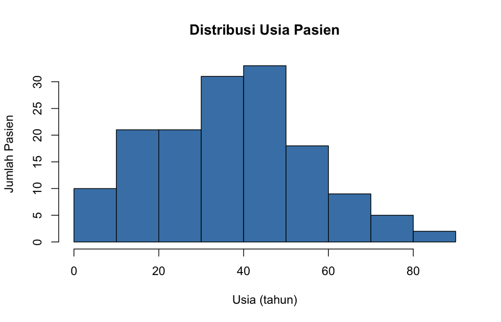

```r
hist(pasien$usia,
     main = "Distribusi Usia Pasien",
     xlab = "Usia (tahun)",
     ylab = "Jumlah Pasien",
     col = "steelblue")
```

## 6.2 Boxplot

Boxplot dipakai untuk membandingkan distribusi numerik antar kategori.

**Tampilkan kode**

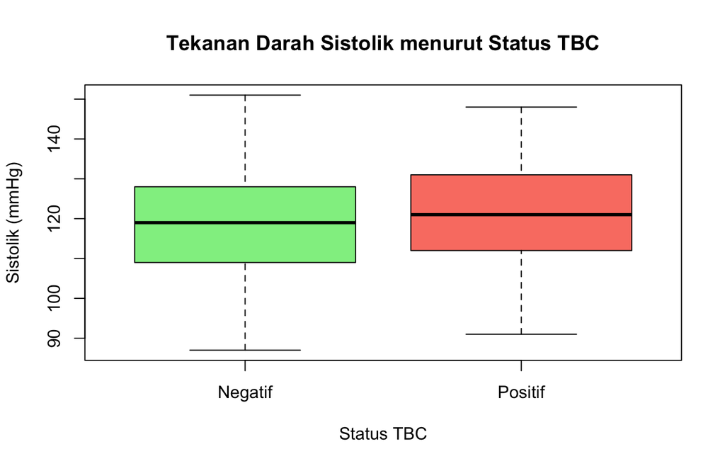

```r
boxplot(tekanan_darah_sistolik ~ status_tbc, data = pasien,
        main = "Tekanan Darah Sistolik menurut Status TBC",
        xlab = "Status TBC", ylab = "Sistolik (mmHg)",
        col = c("lightgreen", "salmon"))
```

## 6.3 Barplot

Barplot dipakai untuk menampilkan jumlah observasi tiap kategori.

**Tampilkan kode**

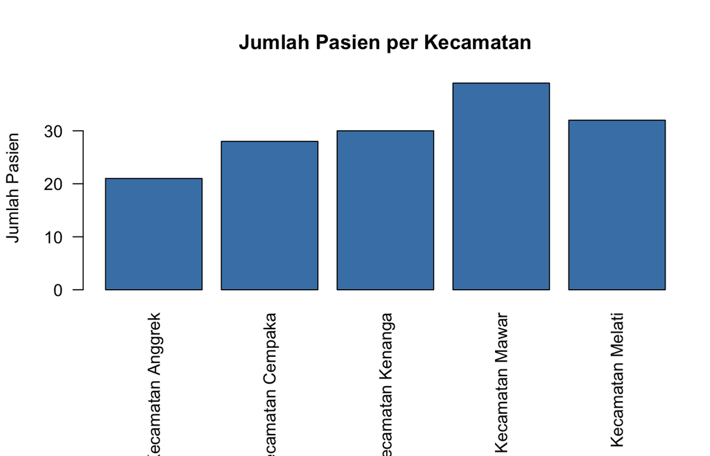

```r
jumlah_per_kecamatan <- table(pasien$kecamatan)
par(mar = c(8, 4, 4, 1) + 0.1)  # tambah margin bawah agar label panjang tidak terpotong
barplot(jumlah_per_kecamatan,
        main = "Jumlah Pasien per Kecamatan",
        ylab = "Jumlah Pasien",
        col = "steelblue",
        las = 2)               # las = 2 memutar label sumbu x
```

**Tampilkan kode**

```r
par(mar = c(5, 4, 4, 2) + 0.1)  # kembalikan margin default
```

## 6.4 Scatter Plot

Scatter plot dipakai untuk melihat hubungan antara dua variabel numerik.

**Tampilkan kode**

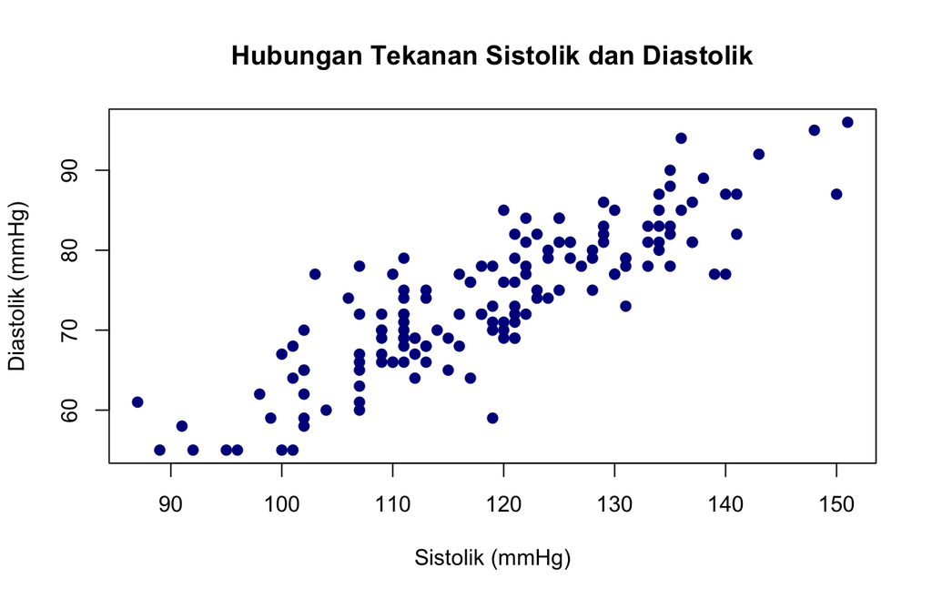

```r
plot(pasien$tekanan_darah_sistolik, pasien$tekanan_darah_diastolik,
     main = "Hubungan Tekanan Sistolik dan Diastolik",
     xlab = "Sistolik (mmHg)", ylab = "Diastolik (mmHg)",
     pch = 19, col = "darkblue")
```

## 6.5 Latihan Mandiri (Sesi 5)

**TipLatihan Mandiri**

1. Buat histogram untuk `suhu_tubuh`, beri judul dan label sumbu yang sesuai
2. Buat boxplot `tekanan_darah_diastolik` menurut `jenis_kelamin`
3. Buat barplot jumlah pasien menurut `status_ekonomi`
4. Buat scatter plot antara `usia` dan `suhu_tubuh`, apakah tampak ada pola hubungan?

Kerjakan di file `scripts/04_visualisasi_dasar.R` sebelum membuka kunci jawaban di bawah ini.

**NoteKunci Jawaban**

**Tampilkan kode**

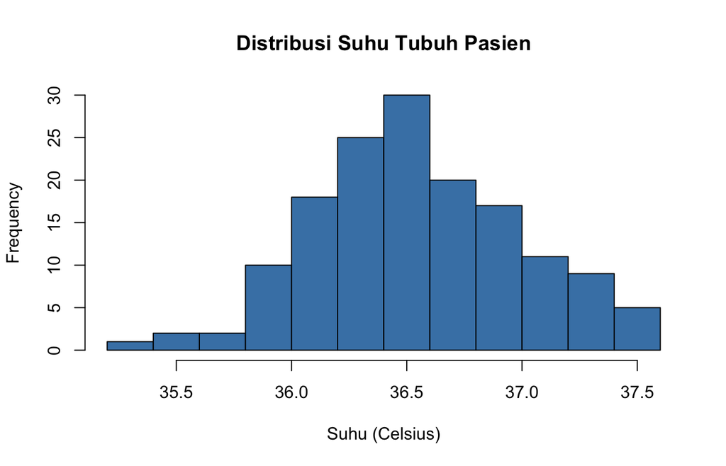

```r
hist(pasien$suhu_tubuh, main = "Distribusi Suhu Tubuh Pasien",
     xlab = "Suhu (Celsius)", col = "steelblue")
```

**Tampilkan kode**

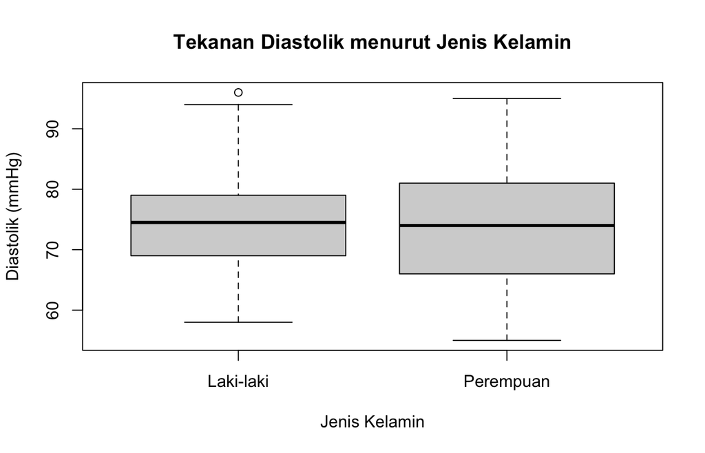

```r
boxplot(tekanan_darah_diastolik ~ jenis_kelamin, data = pasien,
        main = "Tekanan Diastolik menurut Jenis Kelamin",
        xlab = "Jenis Kelamin", ylab = "Diastolik (mmHg)")
```

**Tampilkan kode**

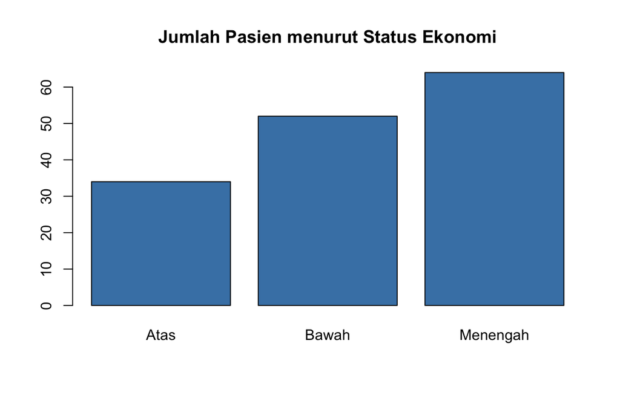

```r
barplot(table(pasien$status_ekonomi),
        main = "Jumlah Pasien menurut Status Ekonomi", col = "steelblue")
```

**Tampilkan kode**

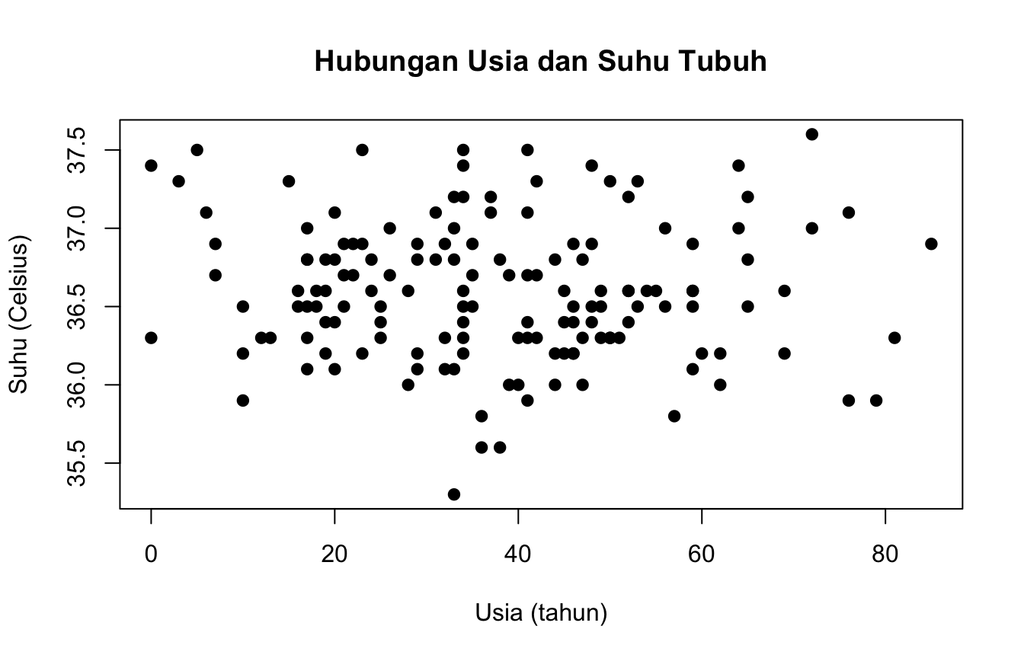

```r
plot(pasien$usia, pasien$suhu_tubuh,
     main = "Hubungan Usia dan Suhu Tubuh",
     xlab = "Usia (tahun)", ylab = "Suhu (Celsius)", pch = 19)
```

# 7 Sesi 6: Studi Kasus Mini, Surveilans TBC Antar Kabupaten

Sesi ini menggabungkan seluruh keterampilan Sesi 1 sampai Sesi 5 dalam satu alur analisis, dari impor data sampai visualisasi.

## 7.1 Tentang Dataset `data_surveilans_tbc_kabupaten.csv`

Dataset agregat bulanan jumlah kasus baru TBC di 5 kabupaten/kota fiktif sepanjang tahun 2025.

| Kolom | Tipe | Keterangan |
| --- | --- | --- |
| kabupaten_kota | character | Nama kabupaten/kota (fiktif) |
| bulan_ke | numeric | Bulan ke-1 sampai ke-12 tahun 2025 |
| nama_bulan | character | Singkatan nama bulan, Jan sampai Des |
| tanggal | character (tanggal) | Tanggal awal bulan |
| jumlah_penduduk | numeric | Jumlah penduduk kabupaten/kota (fiktif) |
| jumlah_kasus_baru | numeric | Jumlah kasus baru TBC pada bulan tersebut |
| cakupan_pengobatan_persen | numeric | Persentase cakupan pengobatan TBC |

## 7.2 Langkah 1: Eksplorasi Data

**Tampilkan kode**

```r
surveilans <- read.csv("data/data_surveilans_tbc_kabupaten.csv")
str(surveilans)
```

```
'data.frame':   60 obs. of  7 variables:
 $ kabupaten_kota           : chr  "Kota Puspanegara" "Kota Puspanegara" "Kota Puspanegara" "Kota Puspanegara" ...
 $ bulan_ke                 : int  1 2 3 4 5 6 7 8 9 10 ...
 $ nama_bulan               : chr  "Jan" "Feb" "Mar" "Apr" ...
 $ tanggal                  : chr  "2025-01-01" "2025-02-01" "2025-03-01" "2025-04-01" ...
 $ jumlah_penduduk          : int  420000 420000 420000 420000 420000 420000 420000 420000 420000 420000 ...
 $ jumlah_kasus_baru        : int  35 24 27 33 41 44 49 36 23 25 ...
 $ cakupan_pengobatan_persen: num  74.7 98 74.7 82.7 82.9 78.7 75.5 84.1 91.2 75.2 ...
```

**Tampilkan kode**

```r
unique(surveilans$kabupaten_kota)
```

```
[1] "Kota Puspanegara"     "Kabupaten Argomulyo"  "Kabupaten Sumberjaya"
[4] "Kabupaten Wonoasri"   "Kabupaten Giritirta"
```

## 7.3 Langkah 2: Hitung Insidensi per 100.000 Penduduk

**Tampilkan kode**

```r
surveilans$insidensi_per100rb <- surveilans$jumlah_kasus_baru / surveilans$jumlah_penduduk * 100000
head(surveilans)
```

|  | kabupaten_kota | bulan_ke | nama_bulan | tanggal | jumlah_penduduk | jumlah_kasus_baru | cakupan_pengobatan_persen | insidensi_per100rb |
| --- | --- | --- | --- | --- | --- | --- | --- | --- |
| 1 | Kota Puspanegara | 1 | Jan | 2025-01-01 | 420000 | 35 | 74.7 | 8.333333 |
| 2 | Kota Puspanegara | 2 | Feb | 2025-02-01 | 420000 | 24 | 98.0 | 5.714286 |
| 3 | Kota Puspanegara | 3 | Mar | 2025-03-01 | 420000 | 27 | 74.7 | 6.428571 |
| 4 | Kota Puspanegara | 4 | Apr | 2025-04-01 | 420000 | 33 | 82.7 | 7.857143 |
| 5 | Kota Puspanegara | 5 | Mei | 2025-05-01 | 420000 | 41 | 82.9 | 9.761905 |
| 6 | Kota Puspanegara | 6 | Jun | 2025-06-01 | 420000 | 44 | 78.7 | 10.476190 |

## 7.4 Langkah 3: Rata-rata Insidensi per Kabupaten

**Tampilkan kode**

```r
rata_insidensi_kabupaten <- aggregate(insidensi_per100rb ~ kabupaten_kota, data = surveilans, FUN = mean)
rata_insidensi_kabupaten <- rata_insidensi_kabupaten[order(rata_insidensi_kabupaten$insidensi_per100rb, decreasing = TRUE), ]
rata_insidensi_kabupaten
```

|  | kabupaten_kota | insidensi_per100rb |
| --- | --- | --- |
| 3 | Kabupaten Sumberjaya | 12.787879 |
| 2 | Kabupaten Giritirta | 9.953704 |
| 5 | Kota Puspanegara | 7.876984 |
| 1 | Kabupaten Argomulyo | 6.256831 |
| 4 | Kabupaten Wonoasri | 5.256410 |

## 7.5 Langkah 4: Visualisasi, Rata-rata Insidensi per Kabupaten

**Tampilkan kode**

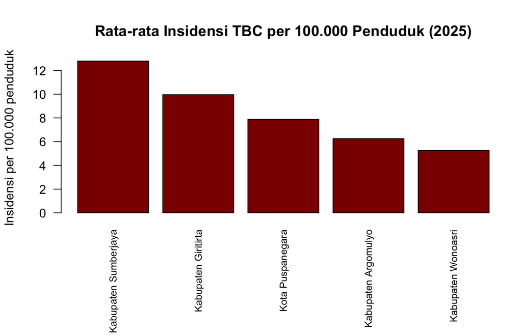

```r
par(mar = c(8, 4, 4, 1) + 0.1)  # tambah margin bawah agar label panjang tidak terpotong
barplot(rata_insidensi_kabupaten$insidensi_per100rb,
        names.arg = rata_insidensi_kabupaten$kabupaten_kota,
        main = "Rata-rata Insidensi TBC per 100.000 Penduduk (2025)",
        ylab = "Insidensi per 100.000 penduduk",
        col = "darkred", las = 2, cex.names = 0.8)
```

**Tampilkan kode**

```r
par(mar = c(5, 4, 4, 2) + 0.1)  # kembalikan margin default
```

## 7.6 Langkah 5: Visualisasi, Tren Bulanan Tiap Kabupaten

**Tampilkan kode**

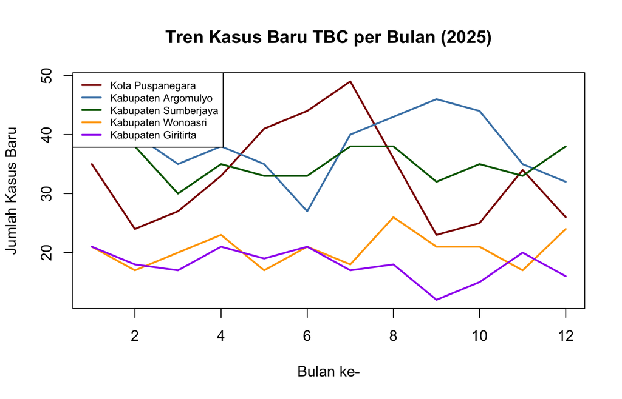

```r
kabupaten_list <- unique(surveilans$kabupaten_kota)
warna <- c("darkred", "steelblue", "darkgreen", "orange", "purple")

plot(NULL, type = "n",
     xlim = c(1, 12), ylim = range(surveilans$jumlah_kasus_baru),
     main = "Tren Kasus Baru TBC per Bulan (2025)",
     xlab = "Bulan ke-", ylab = "Jumlah Kasus Baru")

for (i in seq_along(kabupaten_list)) {
  data_k <- subset(surveilans, kabupaten_kota == kabupaten_list[i])
  data_k <- data_k[order(data_k$bulan_ke), ]
  lines(data_k$bulan_ke, data_k$jumlah_kasus_baru, col = warna[i], lwd = 2)
}
legend("topleft", legend = kabupaten_list, col = warna, lwd = 2, cex = 0.7)
```

## 7.7 Latihan Mandiri (Sesi 6)

**TipLatihan Mandiri**

1. Kabupaten/kota mana yang memiliki total kasus baru paling sedikit sepanjang 2025?
2. Bulan ke berapa yang secara keseluruhan memiliki jumlah kasus baru tertinggi jika dijumlahkan dari semua kabupaten? Gunakan `aggregate()` dengan formula `jumlah_kasus_baru ~ bulan_ke`
3. Buat boxplot `cakupan_pengobatan_persen` menurut `kabupaten_kota`
4. Menurut Anda, kabupaten/kota mana yang paling perlu menjadi prioritas intervensi jika mempertimbangkan insidensi dan cakupan pengobatan sekaligus?

Kerjakan di file `scripts/05_studi_kasus.R` sebelum membuka kunci jawaban di bawah ini.

**NoteKunci Jawaban**

**Tampilkan kode**

```r
total_kasus_kabupaten <- aggregate(jumlah_kasus_baru ~ kabupaten_kota, data = surveilans, FUN = sum)
total_kasus_kabupaten[order(total_kasus_kabupaten$jumlah_kasus_baru), ][1, ]
```

|  | kabupaten_kota | jumlah_kasus_baru |
| --- | --- | --- |
| 2 | Kabupaten Giritirta | 215 |

**Tampilkan kode**

```r
total_per_bulan <- aggregate(jumlah_kasus_baru ~ bulan_ke, data = surveilans, FUN = sum)
total_per_bulan[order(total_per_bulan$jumlah_kasus_baru, decreasing = TRUE), ][1, ]
```

|  | bulan_ke | jumlah_kasus_baru |
| --- | --- | --- |
| 7 | 7 | 162 |

**Tampilkan kode**

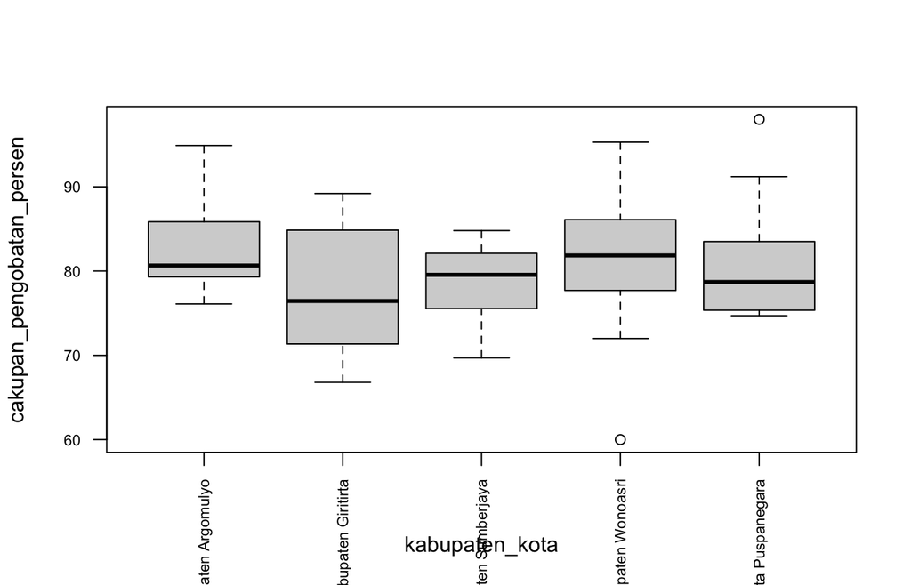

```r
boxplot(cakupan_pengobatan_persen ~ kabupaten_kota, data = surveilans,
        las = 2, cex.axis = 0.7)
```

Pertanyaan nomor 4 bersifat interpretatif. Pertimbangan umum yang lazim dipakai: kabupaten/kota dengan insidensi tinggi namun cakupan pengobatan rendah umumnya menjadi prioritas utama, karena mengindikasikan beban penyakit tinggi yang tidak diimbangi penanganan memadai. Diskusikan bersama fasilitator dan peserta lain.

# 8 Penutup: Preview Tidyverse

Bagian ini bersifat gambaran umum, bukan pengajaran mendalam. Tujuannya menunjukkan bahwa konsep base R yang baru dipelajari, yaitu filtering, membuat kolom baru, agregasi, dan visualisasi, tetap sama, hanya sintaksnya berbeda saat memakai tidyverse.

**Tampilkan kode**

```r
library(dplyr)
library(ggplot2)
```

## 8.1 Perbandingan 1: Filtering Baris

**Tampilkan kode**

```r
# base R
subset(pasien, usia > 60 & status_tbc == "Positif")
```

|  | id_pasien | usia | jenis_kelamin | kecamatan | status_ekonomi | tekanan_darah_sistolik | tekanan_darah_diastolik | suhu_tubuh | gejala_batuk | status_tbc | tanggal_kunjungan | kategori_usia | tekanan_tinggi |
| --- | --- | --- | --- | --- | --- | --- | --- | --- | --- | --- | --- | --- | --- |
| 27 | P027 | 69 | Laki-laki | Kecamatan Anggrek | Atas | 131 | 79 | 36.6 | Tidak | Positif | 2025-03-23 | Lansia | Tidak |
| 30 | P030 | 69 | Laki-laki | Kecamatan Anggrek | Atas | 143 | 92 | 36.2 | Ya | Positif | 2025-02-05 | Lansia | Ya |
| 77 | P077 | 76 | Laki-laki | Kecamatan Melati | Menengah | 131 | 73 | 37.1 | Ya | Positif | 2025-02-04 | Lansia | Tidak |
| 132 | P132 | 85 | Perempuan | Kecamatan Cempaka | Bawah | 135 | 88 | 36.9 | Tidak | Positif | 2025-01-17 | Lansia | Tidak |

**Tampilkan kode**

```r
# dplyr
pasien %>%
  filter(usia > 60, status_tbc == "Positif")
```

| id_pasien | usia | jenis_kelamin | kecamatan | status_ekonomi | tekanan_darah_sistolik | tekanan_darah_diastolik | suhu_tubuh | gejala_batuk | status_tbc | tanggal_kunjungan | kategori_usia | tekanan_tinggi |
| --- | --- | --- | --- | --- | --- | --- | --- | --- | --- | --- | --- | --- |
| P027 | 69 | Laki-laki | Kecamatan Anggrek | Atas | 131 | 79 | 36.6 | Tidak | Positif | 2025-03-23 | Lansia | Tidak |
| P030 | 69 | Laki-laki | Kecamatan Anggrek | Atas | 143 | 92 | 36.2 | Ya | Positif | 2025-02-05 | Lansia | Ya |
| P077 | 76 | Laki-laki | Kecamatan Melati | Menengah | 131 | 73 | 37.1 | Ya | Positif | 2025-02-04 | Lansia | Tidak |
| P132 | 85 | Perempuan | Kecamatan Cempaka | Bawah | 135 | 88 | 36.9 | Tidak | Positif | 2025-01-17 | Lansia | Tidak |

## 8.2 Perbandingan 2: Agregasi

**Tampilkan kode**

```r
# base R
aggregate(tekanan_darah_sistolik ~ kecamatan, data = pasien, FUN = mean)
```

| kecamatan | tekanan_darah_sistolik |
| --- | --- |
| Kecamatan Anggrek | 124.5714 |
| Kecamatan Cempaka | 118.1786 |
| Kecamatan Kenanga | 114.0000 |
| Kecamatan Mawar | 120.5385 |
| Kecamatan Melati | 118.4688 |

**Tampilkan kode**

```r
# dplyr
pasien %>%
  group_by(kecamatan) %>%
  summarise(rata_sistolik = mean(tekanan_darah_sistolik))
```

| kecamatan | rata_sistolik |
| --- | --- |
| Kecamatan Anggrek | 124.5714 |
| Kecamatan Cempaka | 118.1786 |
| Kecamatan Kenanga | 114.0000 |
| Kecamatan Mawar | 120.5385 |
| Kecamatan Melati | 118.4688 |

## 8.3 Perbandingan 3: Visualisasi

**Tampilkan kode**

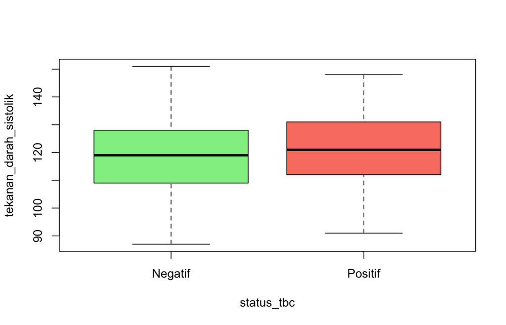

```r
# base R
boxplot(tekanan_darah_sistolik ~ status_tbc, data = pasien,
        col = c("lightgreen", "salmon"))
```

**Tampilkan kode**

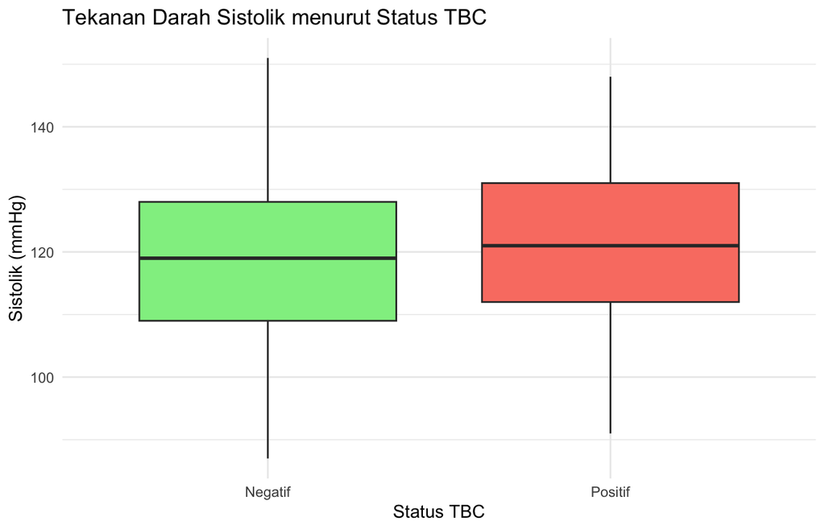

```r
# ggplot2
ggplot(pasien, aes(x = status_tbc, y = tekanan_darah_sistolik, fill = status_tbc)) +
  geom_boxplot() +
  scale_fill_manual(values = c("Negatif" = "lightgreen", "Positif" = "salmon")) +
  labs(title = "Tekanan Darah Sistolik menurut Status TBC",
       x = "Status TBC", y = "Sistolik (mmHg)") +
  theme_minimal() +
  theme(legend.position = "none")
```

## 8.4 Langkah Belajar Lanjutan

- **dplyr**, untuk manipulasi data: `filter()`, `select()`, `mutate()`, `group_by()`, `summarise()`, `arrange()`
- **ggplot2**, grammar of graphics untuk visualisasi: `geom_point()`, `geom_bar()`, `geom_line()`, `facet_wrap()`
- **tidyr**, untuk merapikan bentuk data: `pivot_longer()`, `pivot_wider()`
- **Quarto**, untuk menulis laporan analisis yang reproducible, menggabungkan narasi, kode, dan hasil dalam satu dokumen seperti panduan ini

# 9 Lampiran

## 9.1 Kamus Data Lengkap

### 9.1.1 `data_pasien_puskesmas.csv`

| Kolom | Tipe | Keterangan |
| --- | --- | --- |
| id_pasien | character | Kode identitas pasien |
| usia | numeric | Usia pasien dalam tahun |
| jenis_kelamin | character | Laki-laki atau Perempuan |
| kecamatan | character | Kecamatan tempat tinggal pasien (fiktif) |
| status_ekonomi | character | Bawah, Menengah, atau Atas |
| tekanan_darah_sistolik | numeric | mmHg |
| tekanan_darah_diastolik | numeric | mmHg |
| suhu_tubuh | numeric | Derajat Celsius |
| gejala_batuk | character | Ya atau Tidak |
| status_tbc | character | Positif atau Negatif |
| tanggal_kunjungan | character (tanggal) | Format YYYY-MM-DD |

### 9.1.2 `data_surveilans_tbc_kabupaten.csv`

| Kolom | Tipe | Keterangan |
| --- | --- | --- |
| kabupaten_kota | character | Nama kabupaten/kota (fiktif) |
| bulan_ke | numeric | 1 sampai 12 |
| nama_bulan | character | Jan sampai Des |
| tanggal | character (tanggal) | Tanggal awal bulan, format YYYY-MM-DD |
| jumlah_penduduk | numeric | Jumlah penduduk (fiktif) |
| jumlah_kasus_baru | numeric | Jumlah kasus baru TBC per bulan |
| cakupan_pengobatan_persen | numeric | Persentase cakupan pengobatan |

## 9.2 Daftar File Workshop

```
Workshop Intro R/
├── rundown_workshop.md
├── panduan_instalasi.qmd
├── panduan_instalasi.html
├── panduan_workshop.qmd
├── panduan_workshop.html
├── data/
│   ├── data_pasien_puskesmas.csv
│   └── data_surveilans_tbc_kabupaten.csv
├── data-raw/
│   └── 00_generate_data.R
└── scripts/
    ├── 01_dasar_r.R
    ├── 02_impor_eksplorasi.R
    ├── 03_manipulasi_data.R
    ├── 04_visualisasi_dasar.R
    ├── 05_studi_kasus.R
    └── 06_preview_tidyverse.R
```

## 9.3 Troubleshooting Umum

| Pesan Error | Penyebab Umum | Solusi |
| --- | --- | --- |
| `could not find function` | Fungsi berasal dari paket yang belum dimuat | Jalankan `library(nama_paket)` terlebih dahulu |
| `object 'x' not found` | Nama variabel salah ketik, atau baris yang membuat variabel tersebut belum dijalankan | Periksa ejaan nama variabel, jalankan ulang baris sebelumnya secara berurutan |
| `cannot open file, No such file or directory` | Working directory tidak sesuai lokasi folder `Workshop Intro R` | Cek dengan `getwd()`, atur ulang lewat Session > Set Working Directory |
| `unexpected symbol` atau `unexpected ','` | Tanda kurung atau tanda kutip tidak lengkap | Periksa kembali pasangan `(`, `)`, `"`, dan `'` pada baris kode |